# Card 데이터 분석

김광률

2021년 2월 4일

# 1_card_분석전 기본세팅

### 패키지 및 라이브러리

```r
library(dplyr)
```

```r
library(ggplot2)
```

### 데이터 가지고 놀 폴더지정

```r
#getwd()
#setwd("C:/Users/GWANGRYUL/Desktop/스터디/카드/카드데이터1/data04")
```

### 데이터 불러오기

```r
train <- read.csv("C:/Users/GWANGRYUL/Desktop/스터디/카드/카드데이터1/data04/train.csv")
#test <- read.csv("test.csv")
attach(train)
#attach(test)
```

### 오타수정

```r
colnames(train)[8] <- "holiday"
#colnames(test)[8] <- "holiday"
```

### 데이터 둘러보기

```r
names(train)
```

```
## [1] "store_id"     "date"         "time"         "card_id"      "amount"
## [6] "installments" "days_of_week" "holiday"
```

```r
#names(test)
length(unique(train$store_id))
```

```
## [1] 1775
```

```r
#length(unique(test$store_id))
head(train)
```

```
##   store_id       date     time    card_id amount installments days_of_week
## 1        0 2016-12-14 18:05:31 d297bba73f      5           NA            2
## 2        0 2016-12-14 18:05:54 d297bba73f     -5           NA            2
## 3        0 2016-12-19 12:42:31 0880849c05    144           NA            0
## 4        0 2016-12-19 12:48:08 8b4f9e0e95     66           NA            0
## 5        0 2016-12-19 13:31:08 7ad237eed0     24           NA            0
## 6        0 2016-12-19 13:36:39 30b1422f77     44           NA            0
##   holiday
## 1       0
## 2       0
## 3       0
## 4       0
## 5       0
## 6       0
```

# 2_전처리(시계열관련변수)

## 시계열 관련 변수들

### 연, 월, 일, 시, 분, 초 변수 추가

```r
train$year = as.numeric(substr(train$date, 1,4)) #년도만 숫자형태로 따옴
train$month = as.numeric(substr(train$date, 6,7)) #월만 숫자형태로 따옴
train$day = as.numeric(substr(train$date, 9,10)) #일만 숫자형태로 따옴
train$hour = as.numeric(substr(train$time, 1,2)) #Hour만 숫자형태로 따옴
train$min = as.numeric(substr(train$time, 4,5)) #Minute만 숫자형태로 따옴
train$sec = as.numeric(substr(train$time, 7,8)) #Second만 숫자형태로 따옴
head(train)
```

```
##   store_id       date     time    card_id amount installments days_of_week
## 1        0 2016-12-14 18:05:31 d297bba73f      5           NA            2
## 2        0 2016-12-14 18:05:54 d297bba73f     -5           NA            2
## 3        0 2016-12-19 12:42:31 0880849c05    144           NA            0
## 4        0 2016-12-19 12:48:08 8b4f9e0e95     66           NA            0
## 5        0 2016-12-19 13:31:08 7ad237eed0     24           NA            0
## 6        0 2016-12-19 13:36:39 30b1422f77     44           NA            0
##   holiday year month day hour min sec
## 1       0 2016    12  14   18   5  31
## 2       0 2016    12  14   18   5  54
## 3       0 2016    12  19   12  42  31
## 4       0 2016    12  19   12  48   8
## 5       0 2016    12  19   13  31   8
## 6       0 2016    12  19   13  36  39
```

## 각 스토어별 시간대별 거래빈도 (하루를 4시간*6개로 나누자)

### 각 스토어별 time

2시-6시(새벽)

6시-10시(아침&출근)

10시-14시(낮&점심)

14시-18시(오후&일과)

18시-22시(저녁&퇴근이후)

22시-2시(심야)

```r
hour1 = train %>% #2시~6시(새벽)
  filter(amount >= 0) %>% filter(hour >=2 & hour<6) %>%
  group_by(store_id) %>% tally()

hour2 = train %>% #6시~10시(아침&출근)
  filter(amount >= 0) %>% filter(hour >=6 & hour<10) %>%
  group_by(store_id) %>% tally()

hour3 = train %>% #10시~14시(낮&점심)
  filter(amount >= 0) %>% filter(hour >=10 & hour<14) %>%
  group_by(store_id) %>% tally()
hour4 = train %>% #14시~18시(오후&일과)
  filter(amount >= 0) %>% filter(hour >=14 & hour<18) %>%
  group_by(store_id) %>% tally()

hour5 = train %>% #18시~22시(저녁&퇴근이후)
  filter(amount >= 0) %>% filter(hour >=18 & hour<22) %>%
  group_by(store_id) %>% tally()

hour6 = train %>% #22시~2시(심야)
  filter(amount >= 0) %>% filter(hour ==0|hour==1|hour==22|hour==23) %>%
  group_by(store_id) %>% tally()
```

### 각 store별 월별 거래빈도 & 평균amount

```r
month_count =
  train %>% filter(!is.na(amount)) %>% filter(amount >=0) %>%
  select(store_id, month) %>%
  group_by(store_id, month) %>% tally()


month_avg =
  train %>% filter(!is.na(amount)) %>% filter(amount >=0) %>%
  select(store_id, month, amount) %>%
  group_by(store_id, month)  %>% summarise(mean_month = mean(amount))
```

### 각 store별 요일별 거래빈도 & 평균amount

```r
week_count =
  train %>% select(store_id, month) %>%
  group_by(store_id, train$days_of_week) %>% tally()
colnames(week_count)[2] = 'days_of_week'

week_avg =
  train %>% select(store_id, month, amount) %>%
  group_by(store_id, train$days_of_week)  %>% summarise(mean_month = mean(amount))
colnames(week_avg)[2] = 'days_of_week'
```

### 각 store별 공휴일/비공휴일별 거래빈도 & 평균amount

```r
holiday_count =
  train %>%
  select(store_id, month) %>%
  group_by(store_id, train$holiday) %>% tally()
colnames(holiday_count)[2] = 'holiday'

holiday_avg =
  train %>%
  select(store_id, month, amount) %>%
  group_by(store_id, train$holiday)  %>% summarise(mean_month = mean(amount))
colnames(holiday_avg)[2] = 'holiday'
```

# 3_전처리(store_id별 관련 변수들)

### 각 store별 빈도수 계산

```r
count = train %>% filter(!is.na(amount)) %>% filter(amount >= 0) %>%
  group_by(store_id) %>% tally()
head(count)
```

```
## # A tibble: 6 x 2
##   store_id     n
##      <int> <int>
## 1        0 68160
## 2        1    40
## 3        2 16776
## 4        3   380
## 5        4  2077
## 6        5   116
```

거래기록 1번인 가게들

```r
count[count$n==1,]
```

```
## # A tibble: 12 x 2
##    store_id     n
##       <int> <int>
##  1      201     1
##  2      608     1
##  3      632     1
##  4      657     1
##  5      703     1
##  6      727     1
##  7      866     1
##  8      951     1
##  9      991     1
## 10     1263     1
## 11     1530     1
## 12     1605     1
```

### 각 store별 평균 amount양 계산

```r
avg = train %>% filter(!is.na(amount)) %>%
  group_by(store_id) %>% summarize(avg = mean(amount))
head(avg)
```

```
## # A tibble: 6 x 2
##   store_id    avg
##      <int>  <dbl>
## 1        0   76.1
## 2        1 3699.
## 3        2   96.0
## 4        3  164.
## 5        4  130.
## 6        5 1487.
```

거래평균 제일 높은 가게

```r
avg[avg$avg==max(avg$avg),] #거래평균 제일 높은 가게
```

```
## # A tibble: 1 x 2
##   store_id   avg
##      <int> <dbl>
## 1     1600 57750
```

### 각 store별 unique한 카드개수(고객수)

```r
uniq = train %>% select(store_id, card_id)
uniq = unique(uniq) #중복행 제거
uniq = uniq %>% group_by(store_id) %>% tally()
head(uniq)
```

```
## # A tibble: 6 x 2
##   store_id     n
##      <int> <int>
## 1        0 12727
## 2        1     8
## 3        2  9053
## 4        3   231
## 5        4  1176
## 6        5   101
```

## 할부

```r
train$installments[is.na(train$installments)] <- 0 #NA(할부X)를 0 으로 채우기
```

### store별 할부 빈도수

```r
installment_count =
  train %>% select(store_id, installments) %>%
  filter(installments != 0) %>%
  group_by(store_id) %>% tally()
```

나중에 상대빈도로 바꿀필요가 있음(총 거래빈도수가 다르므로)

### 각 store별 평균할부개월수(할부를 한 사람만 계산했음, 일시불로 계산한 사람 제외)

```r
installment_avg =
  train %>% select(store_id, installments) %>%
  filter(!is.na(installments)) %>% filter(installments != 0) %>%
  group_by(store_id) %>% summarise(mean_install = mean(installments))
```

### 각 store별 환불 빈도

```r
minus_amount =
  train %>% select(store_id, amount) %>%
  filter(amount < 0) %>% group_by(store_id) %>% tally()
```

나중에 전체 n으로 나누기(상대도수로 봐야 유의미)

## 공휴일에 문 닫는 store찾기

```r
holiday_count
```

```
## # A tibble: 3,259 x 3
## # Groups:   store_id [1,775]
##    store_id holiday     n
##       <int>   <int> <int>
##  1        0       0 65046
##  2        0       1  3727
##  3        1       0    40
##  4        2       0 16386
##  5        2       1   443
##  6        3       0   380
##  7        3       1     3
##  8        4       0  2030
##  9        4       1    52
## 10        5       0   121
## # ... with 3,249 more rows
```

```r
holiday_running =
  holiday_count %>% select(store_id, train$holiday) %>%
  group_by(store_id) %>% tally()


holiday_close =
  holiday_running %>% filter(n == 1)

holiday_open =
  holiday_running %>% filter(n == 2)
```

### 주7일운영 store vs 주7일이하운영 store

```r
week_count
```

```
## # A tibble: 11,613 x 3
## # Groups:   store_id [1,775]
##    store_id days_of_week     n
##       <int>        <int> <int>
##  1        0            0  9469
##  2        0            1  9645
##  3        0            2  9777
##  4        0            3  9623
##  5        0            4  9718
##  6        0            5 10103
##  7        0            6 10438
##  8        1            0    16
##  9        1            1    10
## 10        1            2     8
## # ... with 11,603 more rows
```

```r
week_running =
  week_count %>% group_by(store_id) %>% tally()
```

#### 주7일운영

```r
week_open =
  week_running %>% filter(n == 7)
```

##### 주7일운영X

```r
week_close =
  week_running %>% filter(n != 7)
```

# 4_변수 총정리

```r
head(train,20)
```

```
##    store_id       date     time    card_id amount installments days_of_week
## 1         0 2016-12-14 18:05:31 d297bba73f      5            0            2
## 2         0 2016-12-14 18:05:54 d297bba73f     -5            0            2
## 3         0 2016-12-19 12:42:31 0880849c05    144            0            0
## 4         0 2016-12-19 12:48:08 8b4f9e0e95     66            0            0
## 5         0 2016-12-19 13:31:08 7ad237eed0     24            0            0
## 6         0 2016-12-19 13:36:39 30b1422f77     44            0            0
## 7         0 2016-12-19 14:00:23 6dd8dad5ab    146            0            0
## 8         0 2016-12-19 14:01:36 a4a425c5d2      6            0            0
## 9         0 2016-12-19 14:09:46 f213c011fe    306            0            0
## 10        0 2016-12-19 14:13:02 a185b7b11f     51            0            0
## 11        0 2016-12-19 14:51:28 5af79433af     26            0            0
## 12        0 2016-12-19 15:25:32 0beb503a74     20            0            0
## 13        0 2016-12-19 16:15:56 3f90c1e570     72            0            0
## 14        0 2016-12-19 16:19:16 1a04d9a6eb     25            0            0
```

[output cut: 27 more lines]

```r
count              #store별 거래빈도수
```

```
## # A tibble: 1,775 x 2
##    store_id     n
##       <int> <int>
##  1        0 68160
##  2        1    40
##  3        2 16776
##  4        3   380
##  5        4  2077
##  6        5   116
##  7        6  2632
##  8        7   120
##  9        8  1139
## 10        9    12
## # ... with 1,765 more rows
```

```r
avg                #store별 평균거래가격
```

```
## # A tibble: 1,775 x 2
##    store_id    avg
##       <int>  <dbl>
##  1        0   76.1
##  2        1 3699.
##  3        2   96.0
##  4        3  164.
##  5        4  130.
##  6        5 1487.
##  7        6  524.
##  8        7  898.
##  9        8  447.
## 10        9 1520
## # ... with 1,765 more rows
```

```r
uniq               #store별 unique한 카드 개수(고객수)
```

```
## # A tibble: 1,775 x 2
##    store_id     n
##       <int> <int>
##  1        0 12727
##  2        1     8
##  3        2  9053
##  4        3   231
##  5        4  1176
##  6        5   101
##  7        6  1899
##  8        7    74
##  9        8   558
## 10        9     9
## # ... with 1,765 more rows
```

```r
installment_count  #store별 할부한 고객수
```

```
## # A tibble: 1,016 x 2
##    store_id     n
##       <int> <int>
##  1        0   250
##  2        1    14
##  3        3     1
##  4        5    16
##  5        6    17
##  6        8     5
##  7        9     8
##  8       12    27
##  9       13     4
## 10       15     2
## # ... with 1,006 more rows
```

```r
installment_avg    #store별 할부한 고객들의 평균 할부개월수
```

```
## # A tibble: 1,016 x 2
##    store_id mean_install
##       <int>        <dbl>
##  1        0         2.69
##  2        1         6.07
##  3        3         2
##  4        5         2.88
##  5        6         2.65
##  6        8         3
##  7        9         5
##  8       12         3.33
##  9       13         3
## 10       15         4
## # ... with 1,006 more rows
```

```r
minus_amount       #store별 환불한 고객수
```

```
## # A tibble: 1,475 x 2
##    store_id     n
##       <int> <int>
##  1        0   613
##  2        2    53
##  3        3     3
##  4        4     5
##  5        5     8
##  6        6    21
##  7        7     2
##  8        8    14
##  9        9     1
## 10       12    50
## # ... with 1,465 more rows
```

```r
month_count        #store별 월별 거래빈도
```

```
## # A tibble: 17,242 x 3
## # Groups:   store_id [1,775]
##    store_id month     n
##       <int> <dbl> <int>
##  1        0     1  6952
##  2        0     2  6043
##  3        0     3  6989
##  4        0     4  6883
##  5        0     5  7250
##  6        0     6  7209
##  7        0     7  7579
##  8        0     8  3949
##  9        0     9  3540
## 10        0    10  3484
## # ... with 17,232 more rows
```

```r
month_avg          #store별 월별 평균거래가격
```

```
## # A tibble: 17,242 x 3
## # Groups:   store_id [1,775]
##    store_id month mean_month
##       <int> <dbl>      <dbl>
##  1        0     1       84.2
##  2        0     2       80.4
##  3        0     3       75.2
##  4        0     4       79.1
##  5        0     5       77.3
##  6        0     6       74.0
##  7        0     7       76.1
##  8        0     8       75.1
##  9        0     9       76.8
## 10        0    10       77.7
## # ... with 17,232 more rows
```

```r
hour1              #store별 2시~6시(새벽) 거래빈도
```

```
## # A tibble: 501 x 2
##    store_id     n
##       <int> <int>
##  1        0  4271
##  2        2   737
##  3        8   245
##  4       12   146
##  5       13   193
##  6       15   129
##  7       16     7
##  8       20     4
##  9       21    76
## 10       24   918
## # ... with 491 more rows
```

```r
hour2              #store별 6시~10시(아침&출근) 거래빈도
```

```
## # A tibble: 699 x 2
##    store_id     n
##       <int> <int>
##  1        0  5740
##  2        2  1368
##  3        5    11
##  4        6     2
##  5       12    29
##  6       14     7
##  7       15    18
##  8       23   476
##  9       24   312
## 10       32     1
## # ... with 689 more rows
```

```r
hour3              #store별 10시~14시(낮&점심) 거래빈도
```

```
## # A tibble: 1,493 x 2
##    store_id     n
##       <int> <int>
##  1        0  8521
##  2        1     1
##  3        2  8447
##  4        3   111
##  5        4  1206
##  6        5    26
##  7        6   990
##  8        7     5
##  9        9     6
## 10       10     1
## # ... with 1,483 more rows
```

```r
hour4              #store별 14시~18시(오후&일과) 거래빈도
```

```
## # A tibble: 1,653 x 2
##    store_id     n
##       <int> <int>
##  1        0 14144
##  2        1    28
##  3        2  2050
##  4        3   238
##  5        4   392
##  6        5    52
##  7        6   414
##  8        7    27
##  9        8     1
## 10        9     5
## # ... with 1,643 more rows
```

```r
hour5              #store별 18시~22시(저녁&퇴근이후) 거래빈도
```

```
## # A tibble: 1,708 x 2
##    store_id     n
##       <int> <int>
##  1        0 23454
##  2        1    11
##  3        2  2902
##  4        3    31
##  5        4   479
##  6        5    26
##  7        6  1209
##  8        7    83
##  9        8    76
## 10        9     1
## # ... with 1,698 more rows
```

```r
hour6              #store별 22시~2시(심야) 거래빈도
```

```
## # A tibble: 1,169 x 2
##    store_id     n
##       <int> <int>
##  1        0 12030
##  2        2  1272
##  3        5     1
##  4        6    17
##  5        7     5
##  6        8   817
##  7       12   310
##  8       13  2261
##  9       14     2
## 10       15    86
## # ... with 1,159 more rows
```

```r
holiday_count      #store별 공휴일/비공휴일 거래빈도수
```

```
## # A tibble: 3,259 x 3
## # Groups:   store_id [1,775]
##    store_id holiday     n
##       <int>   <int> <int>
##  1        0       0 65046
##  2        0       1  3727
##  3        1       0    40
##  4        2       0 16386
##  5        2       1   443
##  6        3       0   380
##  7        3       1     3
##  8        4       0  2030
##  9        4       1    52
## 10        5       0   121
## # ... with 3,249 more rows
```

```r
holiday_avg        #store별 공휴일/비공휴일 평균거래가격
```

```
## # A tibble: 3,259 x 3
## # Groups:   store_id [1,775]
##    store_id holiday mean_month
##       <int>   <int>      <dbl>
##  1        0       0       75.7
##  2        0       1       82.9
##  3        1       0     3699.
##  4        2       0       96.0
##  5        2       1       96.6
##  6        3       0      164.
##  7        3       1      152.
##  8        4       0      130.
##  9        4       1      136.
## 10        5       0     1408.
## # ... with 3,249 more rows
```

```r
holiday_running
```

```
## # A tibble: 1,775 x 2
##    store_id     n
##       <int> <int>
##  1        0     2
##  2        1     1
##  3        2     2
##  4        3     2
##  5        4     2
##  6        5     2
##  7        6     2
##  8        7     2
##  9        8     2
## 10        9     1
## # ... with 1,765 more rows
```

```r
holiday_open       #공휴일에도 영업하는 store
```

```
## # A tibble: 1,484 x 2
##    store_id     n
##       <int> <int>
##  1        0     2
##  2        2     2
##  3        3     2
##  4        4     2
##  5        5     2
##  6        6     2
##  7        7     2
##  8        8     2
##  9       12     2
## 10       13     2
## # ... with 1,474 more rows
```

```r
holiday_close      #공휴일에 영업하지 않는 store
```

```
## # A tibble: 291 x 2
##    store_id     n
##       <int> <int>
##  1        1     1
##  2        9     1
##  3       10     1
##  4       27     1
##  5       31     1
##  6       48     1
##  7       53     1
##  8       61     1
##  9       74     1
## 10       75     1
## # ... with 281 more rows
```

```r
week_count         #store별 요일별 거래빈도수
```

```
## # A tibble: 11,613 x 3
## # Groups:   store_id [1,775]
##    store_id days_of_week     n
##       <int>        <int> <int>
##  1        0            0  9469
##  2        0            1  9645
##  3        0            2  9777
##  4        0            3  9623
##  5        0            4  9718
##  6        0            5 10103
##  7        0            6 10438
##  8        1            0    16
##  9        1            1    10
## 10        1            2     8
## # ... with 11,603 more rows
```

```r
week_avg           #store별 요일별 평균거래가격
```

```
## # A tibble: 11,613 x 3
## # Groups:   store_id [1,775]
##    store_id days_of_week mean_month
##       <int>        <int>      <dbl>
##  1        0            0       75.4
##  2        0            1       73.3
##  3        0            2       72.8
##  4        0            3       74.3
##  5        0            4       77.0
##  6        0            5       79.4
##  7        0            6       80.2
##  8        1            0     2838.
##  9        1            1     5930
## 10        1            2     1650
## # ... with 11,603 more rows
```

```r
week_running
```

```
## # A tibble: 1,775 x 2
##    store_id     n
##       <int> <int>
##  1        0     7
##  2        1     6
##  3        2     7
##  4        3     6
##  5        4     7
##  6        5     7
##  7        6     7
##  8        7     7
##  9        8     7
## 10        9     4
## # ... with 1,765 more rows
```

```r
week_open          #주7일 영업하는 store
```

```
## # A tibble: 1,344 x 2
##    store_id     n
##       <int> <int>
##  1        0     7
##  2        2     7
##  3        4     7
##  4        5     7
##  5        6     7
##  6        7     7
##  7        8     7
##  8       12     7
##  9       13     7
## 10       14     7
## # ... with 1,334 more rows
```

```r
week_close         #주7일 미만 영업하는 store
```

```
## # A tibble: 431 x 2
##    store_id     n
##       <int> <int>
##  1        1     6
##  2        3     6
##  3        9     4
##  4       10     4
##  5       31     6
##  6       42     5
##  7       44     5
##  8       48     5
##  9       49     6
## 10       53     6
## # ... with 421 more rows
```

```r
A = left_join(count , avg, by = c("store_id"="store_id"))
A = left_join(A , uniq, by = c("store_id"="store_id"))
A = left_join(A , installment_count, by = c("store_id"="store_id"))
A = left_join(A , installment_avg, by = c("store_id"="store_id"))
A = left_join(A , minus_amount, by = c("store_id"="store_id"))
#A = left_join(A , month_count, by = c("store_id"="store_id"))
#A = left_join(A , month_avg, by = c("store_id"="store_id"))
#A = left_join(A , holiday_count, by = c("store_id"="store_id"))
#A = left_join(A , holiday_avg, by = c("store_id"="store_id"))
A = left_join(A , holiday_open, by = c("store_id"="store_id"))
A = left_join(A , holiday_close, by = c("store_id"="store_id"))
#A = left_join(A , week_count, by = c("store_id"="store_id"))
#A = left_join(A , week_avg, by = c("store_id"="store_id"))
A = left_join(A , week_open, by = c("store_id"="store_id"))
A = left_join(A , week_close, by = c("store_id"="store_id"))
A = left_join(A , hour1, by = c("store_id"="store_id"))
A = left_join(A , hour2, by = c("store_id"="store_id"))
A = left_join(A , hour3, by = c("store_id"="store_id"))
A = left_join(A , hour4, by = c("store_id"="store_id"))
A = left_join(A , hour5, by = c("store_id"="store_id"))
A = left_join(A , hour6, by = c("store_id"="store_id"))

colnames(A) = c('store_id','count','avg','uniq','installment_count','installment_avg',
                'minus_amount','holiday_open','holiday_close','week_open','week_close',
                'hour2','hour6','hour10','hour14','hour18','hour22')
result = A
head(result,20)
```

```
## # A tibble: 20 x 17
##    store_id count    avg  uniq installment_cou~ installment_avg minus_amount
##       <int> <int>  <dbl> <int>            <int>           <dbl>        <int>
##  1        0 68160   76.1 12727              250            2.69          613
##  2        1    40 3699.      8               14            6.07           NA
##  3        2 16776   96.0  9053               NA           NA              53
##  4        3   380  164.    231                1            2               3
##  5        4  2077  130.   1176               NA           NA               5
##  6        5   116 1487.    101               16            2.88            8
##  7        6  2632  524.   1899               17            2.65           21
##  8        7   120  898.     74               NA           NA               2
##  9        8  1139  447.    558                5            3              14
## 10        9    12 1520       9                8            5               1
## 11       10     7 1301.      7               NA           NA              NA
## 12       12  1302  680.    930               27            3.33           50
## 13       13  4094  141.   2097                4            3              20
## 14       14  1053  201.    377               NA           NA               4
## 15       15   272  135     212                2            4              NA
## 16       16    91  472.     61                2            3               1
## 17       18   937  182.    388               23            2.35            4
## 18       19   314  439.    254                4            2.5             6
## 19       20   137  189.    110               NA           NA               1
## 20       21   402  142.    272               NA           NA               6
## # ... with 10 more variables: holiday_open <int>, holiday_close <int>,
## #   week_open <int>, week_close <int>, hour2 <int>, hour6 <int>, hour10 <int>,
## #   hour14 <int>, hour18 <int>, hour22 <int>
```

# 5_시각화

```r
#(추가)그래프 타이틀 붙여주기
#+ggtitle("그래프 타이틀") +
#  theme(plot.title = element_text(family = "serif", face = "bold", hjust = 0.5, size = 15, color = "darkblue"))
```

## 월

### 월별 거래빈도수

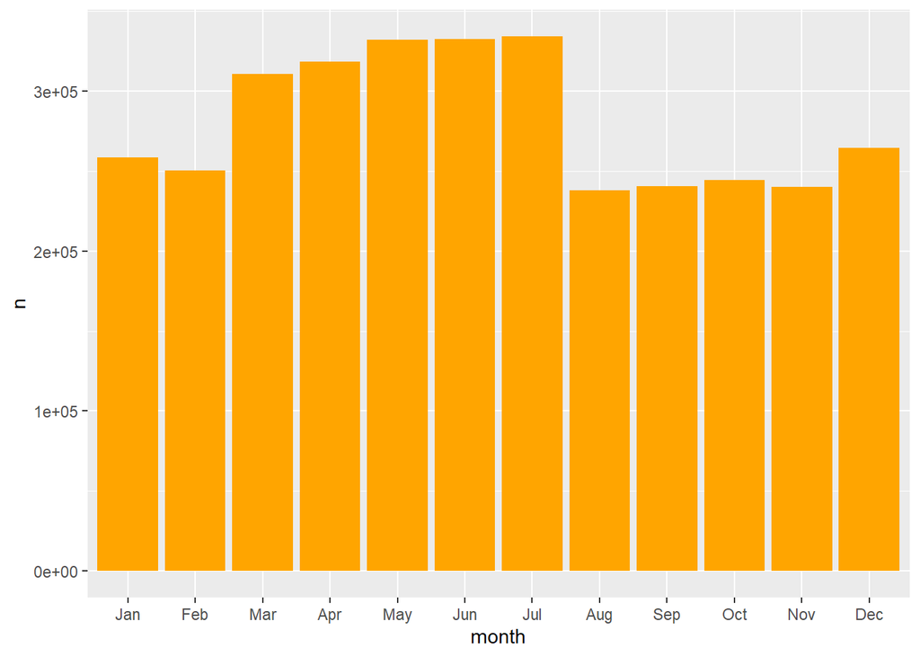

```r
M1 = train %>% group_by(month) %>% tally()
M1$month = c('Jan', 'Feb', 'Mar','Apr','May','Jun', 'Jul','Aug', 'Sep', 'Oct','Nov','Dec')
ggplot(data=M1, aes(x=month, y = n)) + geom_bar(stat = 'identity',fill ='orange1') +
  scale_x_discrete(limits=M1$month)
```

### 월별 평균거래가격

```r
M2 = train %>% group_by(month) %>% summarise(tot_mean = mean(amount))
```

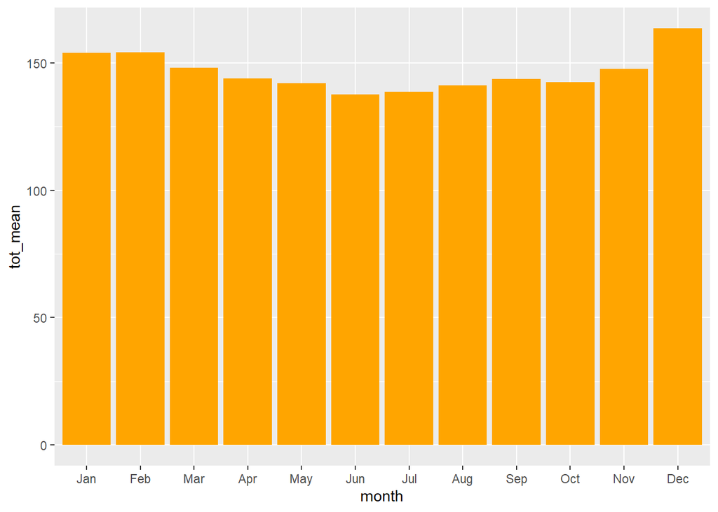

```r
M2$month = c('Jan', 'Feb', 'Mar','Apr','May','Jun', 'Jul','Aug', 'Sep', 'Oct','Nov','Dec')
ggplot(data=M2, aes(x=month, y = tot_mean)) + geom_bar(stat = 'identity',fill ='orange1')+
  scale_x_discrete(limits=M2$month)
```

## 요일

### 요일별 거래빈도수

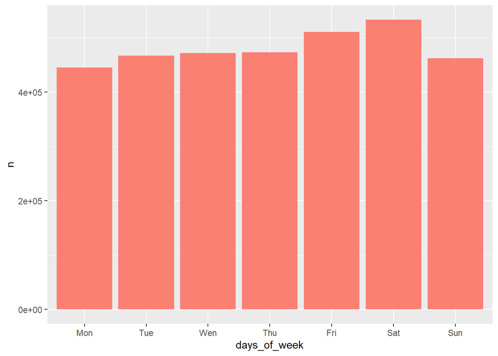

```r
W1 = train %>% group_by(days_of_week) %>% tally()
W1$days_of_week = c('Mon', 'Tue', 'Wen','Thu','Fri','Sat', 'Sun')
ggplot(data=W1, aes(x=days_of_week, y = n)) + geom_bar(stat = 'identity', fill='salmon') +
  scale_x_discrete(limits=W1$days_of_week)
```

### 요일별 평균거래가격

```r
W2 = train %>% group_by(days_of_week) %>% summarise(tot_mean = mean(amount))
```

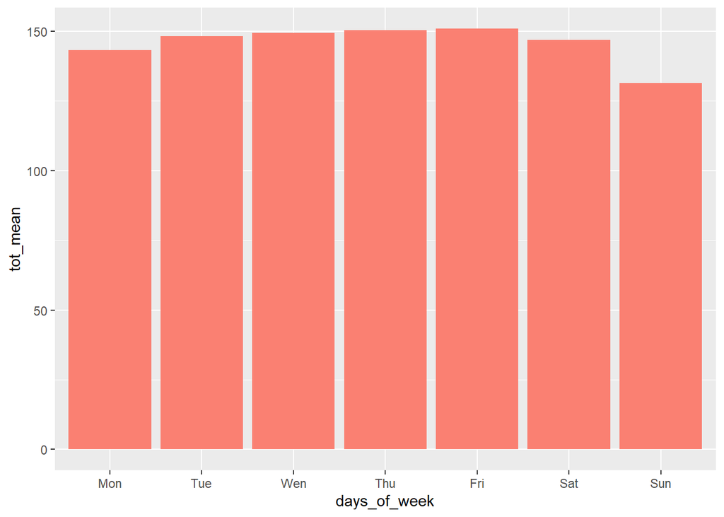

```r
W2$days_of_week = c('Mon', 'Tue', 'Wen','Thu','Fri','Sat', 'Sun')
ggplot(data=W2, aes(x=days_of_week, y = tot_mean)) + geom_bar(stat = 'identity', fill= 'salmon') +
  scale_x_discrete(limits=W2$days_of_week)
```

## 공휴일/비공휴일

### 공휴일/비공휴일 거래빈도수

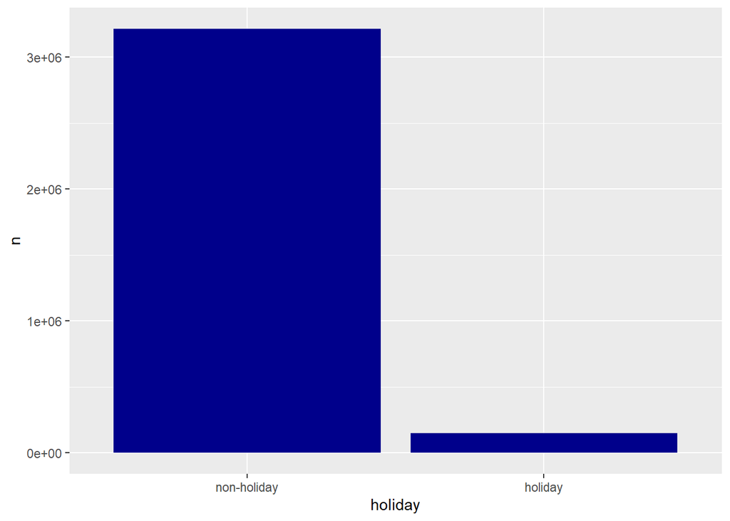

```r
H1 = train %>% group_by(holiday) %>% tally()
H1$holiday = c('non-holiday','holiday')
ggplot(data=H1, aes(x=holiday, y = n)) + geom_bar(stat = 'identity', fill= 'darkblue') +
  scale_x_discrete(limits=H1$holiday)
```

#### 의미없음(평균으로보는게 맞음)

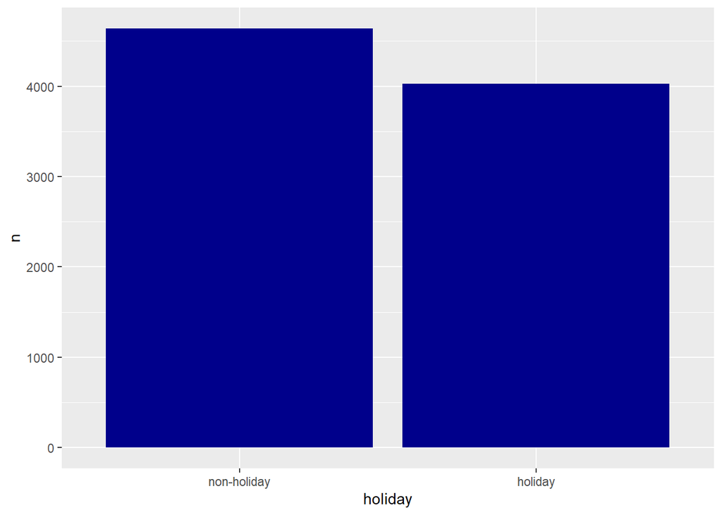

```r
h1 = train %>% select(date, holiday) %>% distinct() %>%
  filter(holiday == 1) %>%  tally() #공휴일수
h0 = train %>% select(date, holiday) %>% distinct() %>%
  filter(holiday == 0) %>%  tally() #비공휴일수
H1$n = H1$n/c(as.numeric(h0),as.numeric(h1))
ggplot(data=H1, aes(x=holiday, y = n)) + geom_bar(stat = 'identity', fill= 'darkblue') +
  scale_x_discrete(limits=H1$holiday)
```

### 공휴일/비공휴일 평균거래가격

```r
H2 = train %>% group_by(holiday) %>% summarise(tot_mean = mean(amount))
```

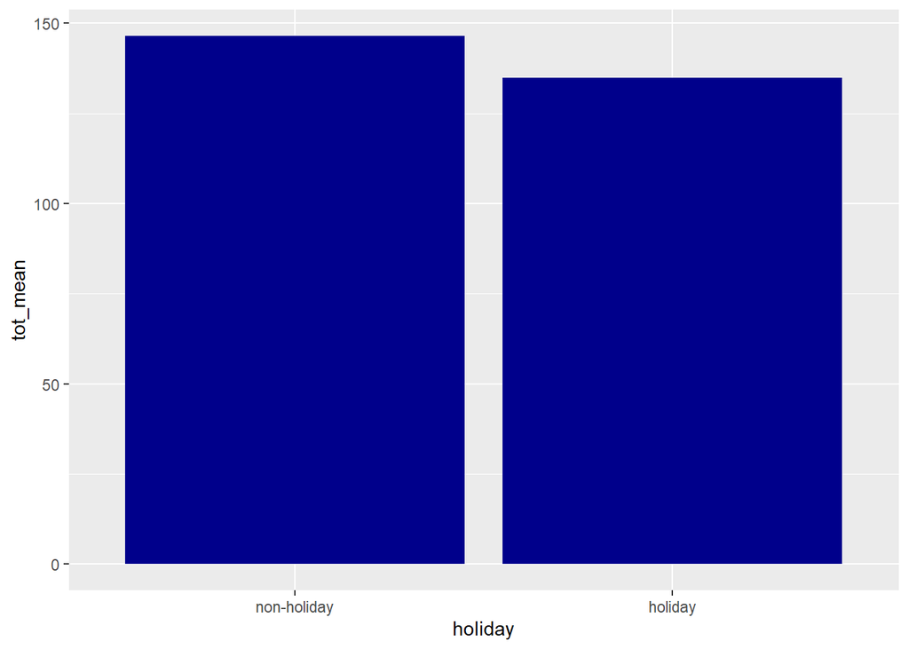

```r
H2$holiday = c('non-holiday','holiday')
ggplot(data=H2, aes(x=holiday, y = tot_mean)) + geom_bar(stat = 'identity', fill= 'darkblue') +
  scale_x_discrete(limits=H2$holiday)
```

## 시간대

### 시간대별 거래빈도수

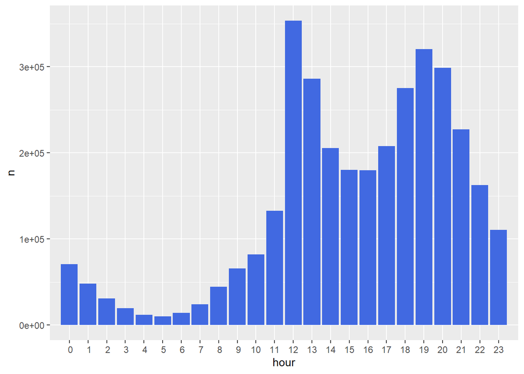

```r
T1 = train %>% group_by(hour) %>% tally()
ggplot(data=T1, aes(x=hour, y = n)) + geom_bar(stat = 'identity', fill="royalblue") +
  scale_x_discrete(limits=T1$hour)
```

### 시간대별 평균거래가격

```r
T2 = train %>% group_by(hour) %>% summarise(tot_mean = mean(amount))
```

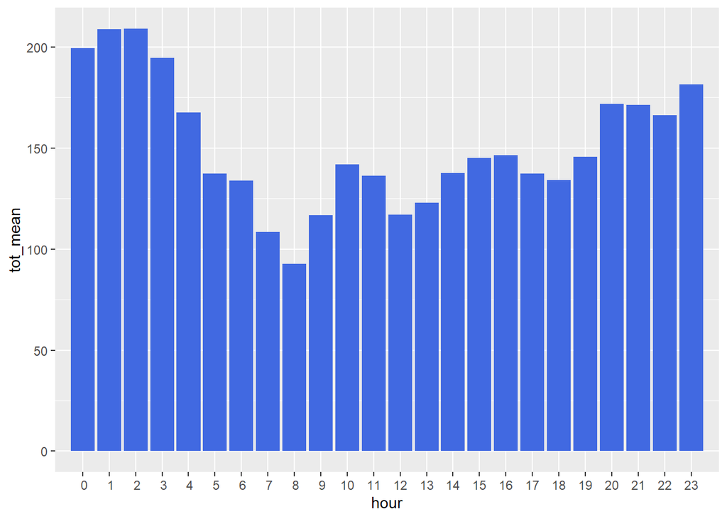

```r
ggplot(data=T2, aes(x=hour, y = tot_mean)) + geom_bar(stat = 'identity',fill='royalblue')+
  scale_x_discrete(limits=T2$hour)
```

## 환불 경향성

### store별 환불비율

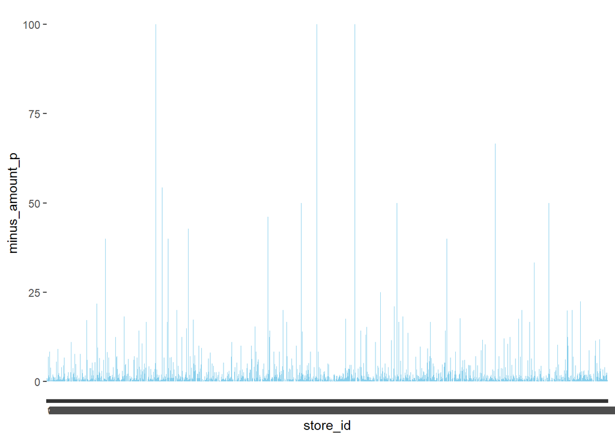

```r
hwan = result %>% select(store_id, count, minus_amount)
hwan[is.na(hwan)] = 0
hwan$minus_amount_p = hwan$minus_amount/hwan$count*100
ggplot(data=hwan, aes(x=store_id, y = minus_amount_p)) + geom_bar(stat = 'identity', fill='skyblue') +
  scale_x_discrete(limits=hwan$store_id)
```

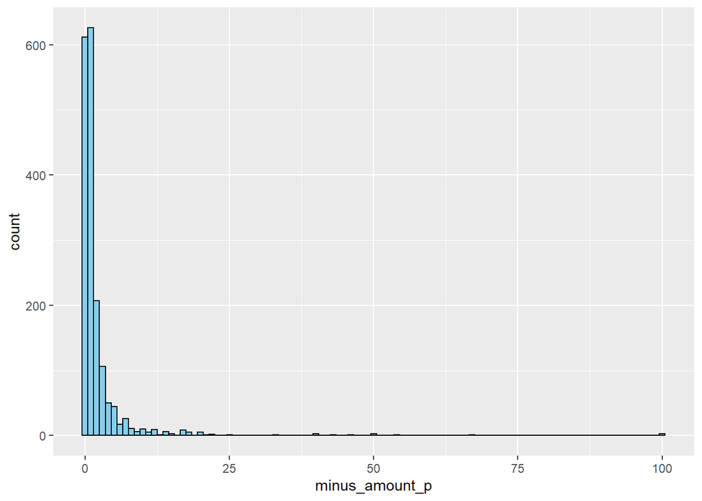

```r
ggplot(data=hwan, aes(x=minus_amount_p)) + geom_histogram(binwidth = 1,color = 'black', fill = 'skyblue')
```

x축:평균환불비율, y축:store의 개수

보통 환불 안하는 경우가 많은듯하다.

#### 로그 씌워봄

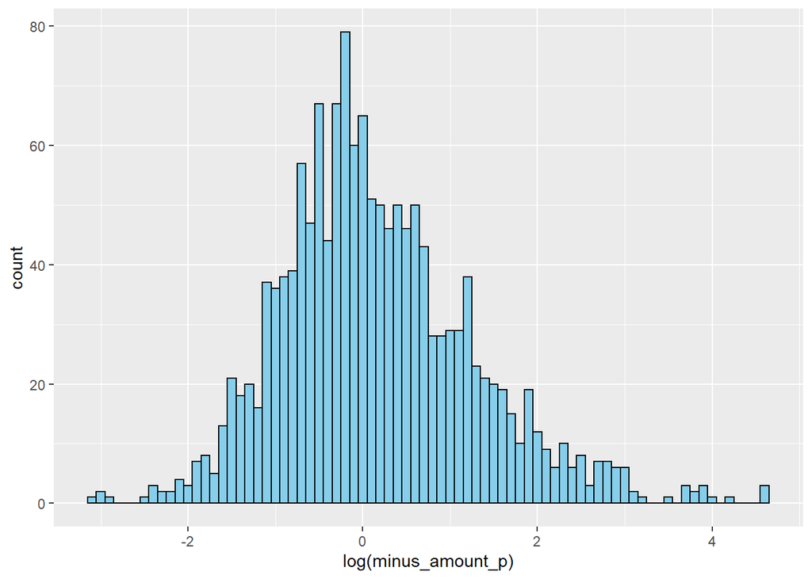

```r
ggplot(data=hwan, aes(x=log(minus_amount_p))) + geom_histogram(binwidth = 0.1,color = 'black', fill = 'skyblue')
```

정규분포와 비슷한 꼴을 보이는 것을 관찰 할 수 있었다.

## 할부 경향성

### store별 평균할부 개월수

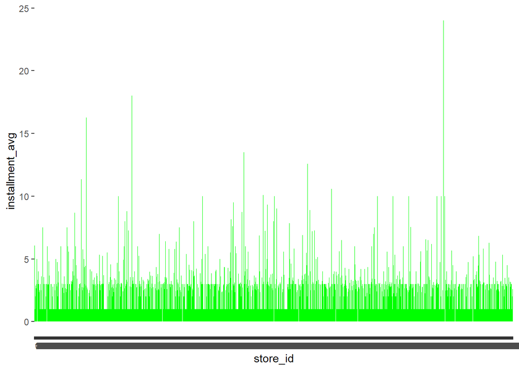

```r
hal = result %>% select(store_id, installment_count, installment_avg)
hal[is.na(hal)] = 1
ggplot(data=hal, aes(x=store_id, y = installment_avg)) + geom_bar(stat = 'identity', fill='green') +
  scale_x_discrete(limits=hal$store_id)
```

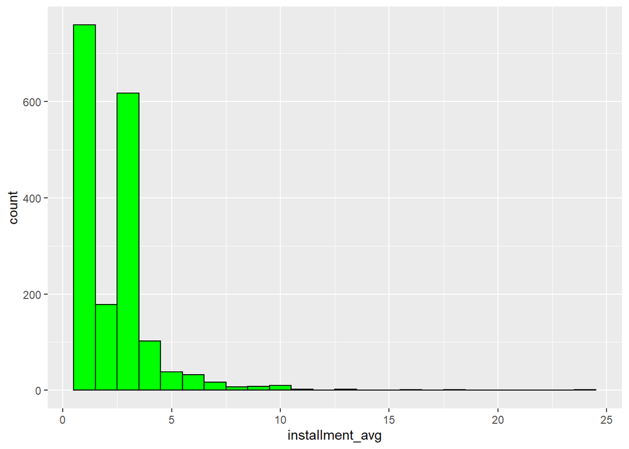

```r
ggplot(data=hal, aes(x=installment_avg)) + geom_histogram(binwidth = 1,color = 'black', fill = 'green')
```

x축:평균할부개월수, y축:store의 개수

보통 일시불(1)과 3개월이 많음

#### 로그 씌워봄

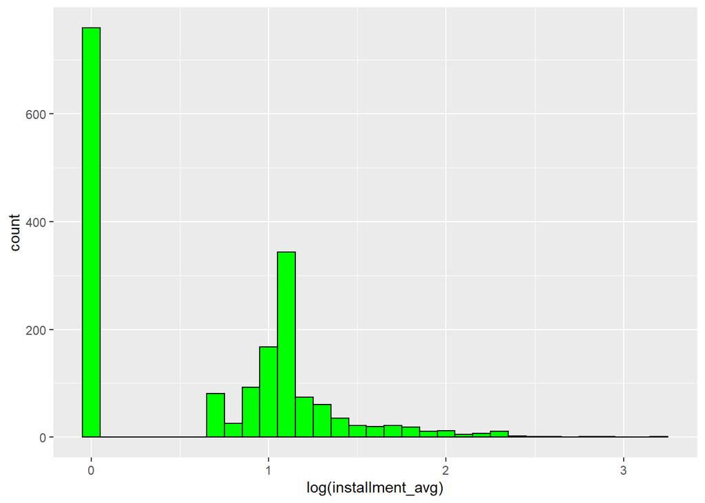

```r
ggplot(data=hal, aes(x=log(installment_avg))) + geom_histogram(binwidth = 0.1,color = 'black', fill = 'green')
```

# 6_군집분석

### 패키지 라이브러리 설치

```r
#install.packages("NbClust")
library(NbClust)
```

#### result데이터셋의 NA값을 0으로 대체한 데이터셋 result0하나 만들어줌(나중에 사용)

```r
result0 = result
result0[is.na(result0)] = 0
```

## 군집분석을 위해 변수 전처리

1. uniq -> uniq/count * 100 (전체결제대비 unique한 고객 비율)
2. installment_count 삭제
3. minus_amount -> minus_amount/count * 100 (전체결제대비 환불결제 비율)
4. hour -> hour/count*100 (시간대별 결제 비율)

```r
clus = result
clus[is.na(clus)] = 0 #결측치 0으로 대체
clus$uniq_p = clus$uniq/clus$count*100
clus$minus_amount_p = clus$minus_amount/clus$count*100
clus$hour2_p = clus$hour2/clus$count*100
clus$hour6_p = clus$hour6/clus$count*100
clus$hour10_p = clus$hour10/clus$count*100
clus$hour14_p = clus$hour14/clus$count*100
clus$hour18_p = clus$hour18/clus$count*100
clus$hour22_p = clus$hour22/clus$count*100

clus = clus[,c(1,2,3,6,8,9,10,11,18:25)] #필요한 변수들만 선택
head(clus)
```

```
## # A tibble: 6 x 16
##   store_id count    avg installment_avg holiday_open holiday_close week_open
##      <int> <int>  <dbl>           <dbl>        <int>         <int>     <int>
## 1        0 68160   76.1            2.69            2             0         7
## 2        1    40 3699.             6.07            0             1         0
## 3        2 16776   96.0            0               2             0         7
## 4        3   380  164.             2               2             0         0
## 5        4  2077  130.             0               2             0         7
## 6        5   116 1487.             2.88            2             0         7
## # ... with 9 more variables: week_close <int>, uniq_p <dbl>,
## #   minus_amount_p <dbl>, hour2_p <dbl>, hour6_p <dbl>, hour10_p <dbl>,
## #   hour14_p <dbl>, hour18_p <dbl>, hour22_p <dbl>
```

### 군집분석을 위해 데이터 컬럼별 정규화(평균:0, 표준편차:1)

```r
clus_scale = scale(clus[,-1]) #store는 군집분석할때는 잠깐 빼줘야함
clus_scale = as.data.frame(clus_scale)
```

### 데이터 형태 중간점검

```r
head(clus,20)
```

```
## # A tibble: 20 x 16
##    store_id count    avg installment_avg holiday_open holiday_close week_open
##       <int> <int>  <dbl>           <dbl>        <int>         <int>     <int>
##  1        0 68160   76.1            2.69            2             0         7
##  2        1    40 3699.             6.07            0             1         0
##  3        2 16776   96.0            0               2             0         7
##  4        3   380  164.             2               2             0         0
##  5        4  2077  130.             0               2             0         7
##  6        5   116 1487.             2.88            2             0         7
##  7        6  2632  524.             2.65            2             0         7
##  8        7   120  898.             0               2             0         7
##  9        8  1139  447.             3               2             0         7
## 10        9    12 1520              5               0             1         0
## 11       10     7 1301.             0               0             1         0
## 12       12  1302  680.             3.33            2             0         7
## 13       13  4094  141.             3               2             0         7
## 14       14  1053  201.             0               2             0         7
## 15       15   272  135              4               2             0         7
## 16       16    91  472.             3               2             0         7
## 17       18   937  182.             2.35            2             0         7
## 18       19   314  439.             2.5             2             0         7
## 19       20   137  189.             0               2             0         7
## 20       21   402  142.             0               2             0         7
## # ... with 9 more variables: week_close <int>, uniq_p <dbl>,
## #   minus_amount_p <dbl>, hour2_p <dbl>, hour6_p <dbl>, hour10_p <dbl>,
## #   hour14_p <dbl>, hour18_p <dbl>, hour22_p <dbl>
```

```r
head(clus_scale,20)
```

```
##          count          avg installment_avg holiday_open holiday_close
## 1  16.52700890 -0.264320736       0.3510247    0.4426976    -0.4426976
## 2  -0.45764637  1.371440109       1.9469500   -2.2576057     2.2576057
## 3   3.71521315 -0.255355643      -0.9202645    0.4426976    -0.4426976
## 4  -0.37287269 -0.224673488       0.0242297    0.4426976    -0.4426976
## 5   0.05024768 -0.240064736      -0.9202645    0.4426976    -0.4426976
## 6  -0.43869696  0.372927426       0.4374459    0.4426976    -0.4426976
## 7   0.18862824 -0.062115112       0.3298014    0.4426976    -0.4426976
## 8  -0.43769962  0.106622344      -0.9202645    0.4426976    -0.4426976
## 9  -0.18362793 -0.096795044       0.4964768    0.4426976    -0.4426976
## 10 -0.46462773  0.387649779       1.4409710   -2.2576057     2.2576057
## 11 -0.46587440  0.288956281      -0.9202645   -2.2576057     2.2576057
## 12 -0.14298643  0.008345432       0.6538925    0.4426976    -0.4426976
## 13  0.55315505 -0.234998298       0.4964768    0.4426976    -0.4426976
## 14 -0.20507068 -0.208106858      -0.9202645    0.4426976    -0.4426976
```

[output cut: 48 more lines]

## Ward 군집분석(군집간 거리를 최대로, 군집의개수를 최대한 고르게 분포할 수 있도록 하기 위해서)

```r
d = dist(clus_scale)
fit.ward = hclust(d, method='ward.D')
```

### 트리모형 그려보기

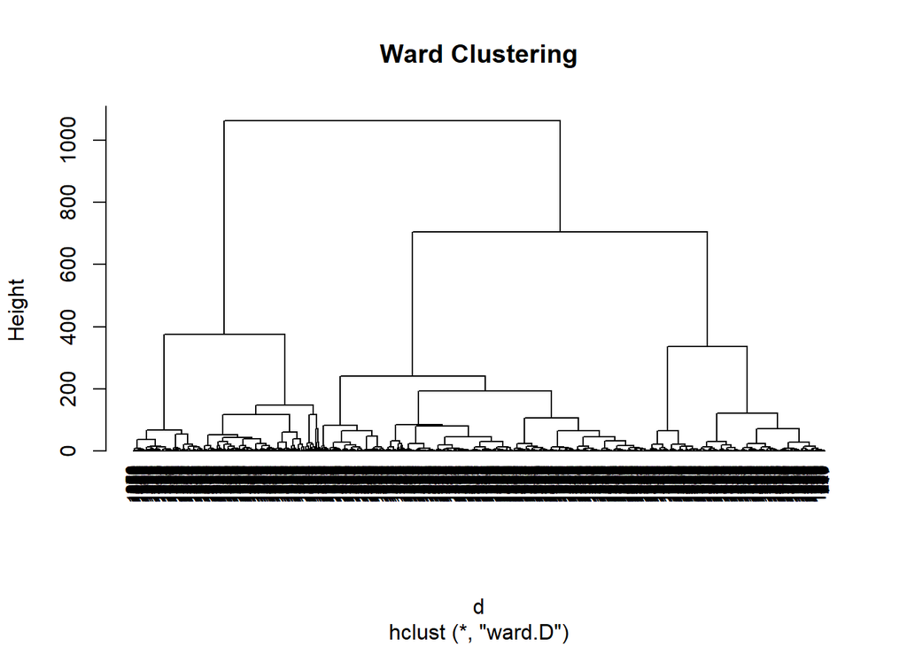

```r
par(mfrow=c(1,1))
plot(fit.ward,hang=-1,cex=.8,main="Ward Clustering")
```

### 몇개의 군집으로 나눌것인가?

```r
devAskNewPage(ask=TRUE)
nc=NbClust(clus_scale[,c(1,2,3,4,6,7,8,9,10,11,12,13,14)], distance="euclidean", min.nc=2, max.nc=15, method="ward.D")
```

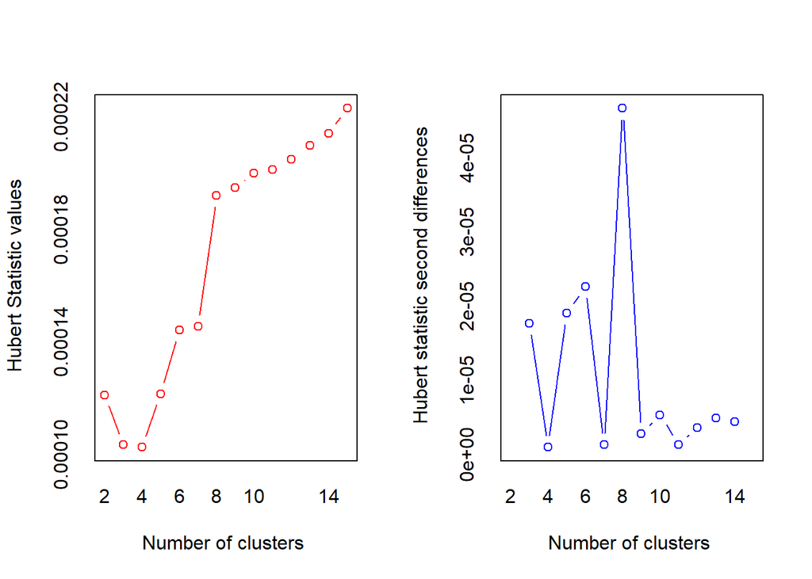

```
## *** : The Hubert index is a graphical method of determining the number of clusters.
##                 In the plot of Hubert index, we seek a significant knee that corresponds to a
##                 significant increase of the value of the measure i.e the significant peak in Hubert
##                 index second differences plot.
##
```

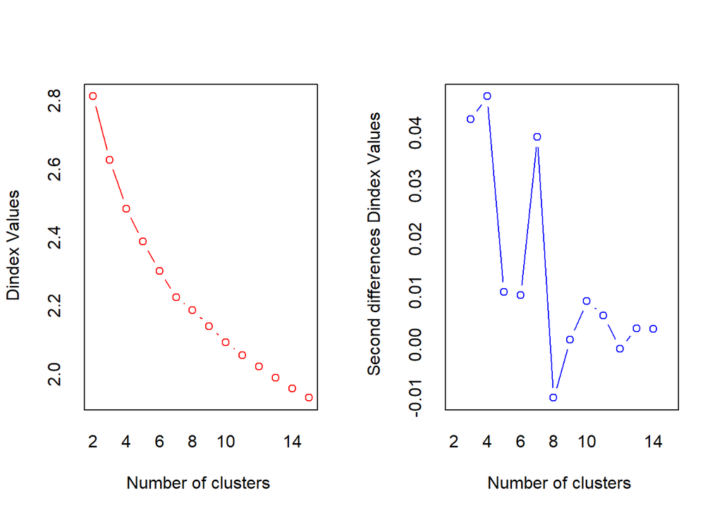

```
## *** : The D index is a graphical method of determining the number of clusters.
##                 In the plot of D index, we seek a significant knee (the significant peak in Dindex
##                 second differences plot) that corresponds to a significant increase of the value of
##                 the measure.
##
## * Among all indices:
## * 5 proposed 2 as the best number of clusters
## * 5 proposed 3 as the best number of clusters
## * 2 proposed 4 as the best number of clusters
## * 1 proposed 5 as the best number of clusters
## * 2 proposed 6 as the best number of clusters
## * 1 proposed 9 as the best number of clusters
## * 1 proposed 10 as the best number of clusters
## * 1 proposed 11 as the best number of clusters
## * 1 proposed 14 as the best number of clusters
## * 3 proposed 15 as the best number of clusters
##
##                    ***** Conclusion *****
##
## * According to the majority rule, the best number of clusters is  2
##
##
```

무한행렬 오류로 인하여

5번째변수(holiday_close) : 6번째변수로 설명이됨(자유도, 배반관계)

15번째변수(hour22_p) : 11,12,13,14변수로 설명이됨 (자유도 문제)는 제외하였음

### 위에서 나온 그래프들을 토대로 군집을 8개로 정함

### 8개로 나눈 군집분석

```r
clusters <- cutree(fit.ward,k=8)
table(clusters)
```

```
## clusters
##   1   2   3   4   5   6   7   8
## 162 261 179 353 328 322 127  43
```

```r
cluster_result = cbind(clusters, clus) #군집분석이 포함된 데이터
head(cluster_result)
```

```
##   clusters store_id count        avg installment_avg holiday_open holiday_close
## 1        1        0 68160   76.11433        2.692000            2             0
## 2        2        1    40 3698.75000        6.071429            0             1
## 3        1        2 16776   95.96886        0.000000            2             0
## 4        3        3   380  163.91906        2.000000            2             0
## 5        4        4  2077  129.83285        0.000000            2             0
## 6        5        5   116 1487.39516        2.875000            2             0
##   week_open week_close   uniq_p minus_amount_p  hour2_p  hour6_p hour10_p
## 1         7          0 18.67224      0.8993545 6.266138 8.421362 12.50147
## 2         0          6 20.00000      0.0000000 0.000000 0.000000  2.50000
## 3         7          0 53.96400      0.3159275 4.393181 8.154506 50.35169
## 4         0          6 60.78947      0.7894737 0.000000 0.000000 29.21053
## 5         7          0 56.62013      0.2407318 0.000000 0.000000 58.06452
## 6         7          0 87.06897      6.8965517 0.000000 9.482759 22.41379
##   hour14_p  hour18_p  hour22_p
## 1 20.75117 34.410211 17.649648
## 2 70.00000 27.500000  0.000000
## 3 12.21984 17.298522  7.582260
## 4 62.63158  8.157895  0.000000
## 5 18.87338 23.062109  0.000000
## 6 44.82759 22.413793  0.862069
```

### 트리구조그림에서의 나뉜 군집의 시각화

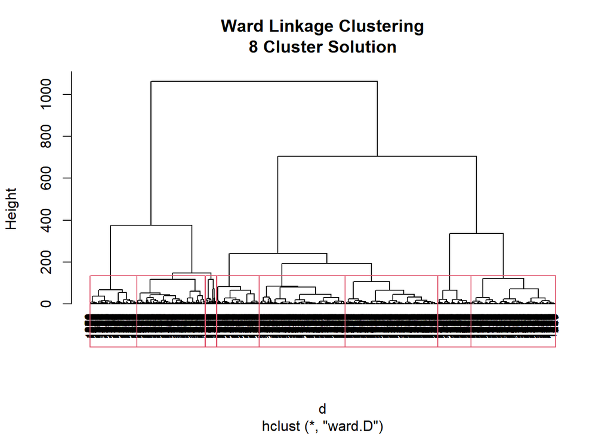

```r
par(mfrow=c(1,1))
plot(fit.ward,hang=-1, cex=.8, main="Ward Linkage Clustering\n8 Cluster Solution")
rect.hclust(fit.ward,k=8)
```

### 군집별 기초통계량보기

```r
g_median = aggregate(clus[,-1],by=list(cluster=clusters),median)
g_mean = aggregate(clus[,-1],by=list(cluster=clusters),mean)
g_max = aggregate(clus[,-1],by=list(cluster=clusters),max)
g_min = aggregate(clus[,-1],by=list(cluster=clusters),min)

#aggregate(as.data.frame(clus),by=list(cluster=clusters),median) 정규화된데이터셋의의 군집통계량
```

### 군집별 기초통계량을 바탕으로 8개 군집의 특성을 잡아보자

```r
g_median
```

```
##   cluster  count       avg installment_avg holiday_open holiday_close week_open
## 1       1 7713.0  57.65495        2.000000            2             0         7
## 2       2   23.0 971.53846        2.500000            0             1         0
## 3       3  116.0 343.25000        2.333333            2             0         0
## 4       4 1446.0 116.50695        0.000000            2             0         7
## 5       5  355.0 282.65488        3.000000            2             0         7
## 6       6  752.5 188.11423        2.000000            2             0         7
## 7       7  405.0 317.04443        2.500000            2             0         7
## 8       8   10.0 323.53968        0.000000            0             1         0
##   week_close   uniq_p minus_amount_p    hour2_p   hour6_p  hour10_p    hour14_p
## 1          0 45.78528      0.5736016  0.0000000  5.962695 26.524473 25.79561309
## 2          5 75.00000      0.0000000  0.0000000  0.000000 24.528302 41.66666667
## 3          6 64.89796      1.0303209  0.0000000  0.000000 23.076923 40.51094891
## 4          0 68.16592      0.7067138  0.0000000  0.000000 31.511372 23.52941176
## 5          0 67.69145      1.2320380  0.0000000  0.000000 26.142840 42.59123731
## 6          0 75.74199      0.7316604  0.3169097  0.000000  0.270981  6.51987241
## 7          0 70.31250      1.2291484 20.0531208  0.000000  0.000000  0.05662514
## 8          2 54.66067      1.3043478  0.0000000 26.582623 33.333333 25.00000000
##    hour18_p  hour22_p
## 1 28.459134  3.235824
## 2 22.222222  0.000000
## 3 25.000000  0.000000
## 4 37.176677  1.187931
## 5 28.059678  0.000000
## 6 54.020954 32.340959
## 7 14.478114 62.288136
## 8  3.333333  0.000000
```

```r
g_mean
```

```
##   cluster       count       avg installment_avg holiday_open holiday_close
## 1       1 10034.58025  144.8444       1.5521407    2.0000000     0.0000000
## 2       2    81.13793 1693.4931       2.1881115    0.0000000     1.0000000
## 3       3   605.05587  605.5467       1.7900323    2.0000000     0.0000000
## 4       4  2048.77337  163.9890       0.7930947    2.0000000     0.0000000
## 5       5   764.89329  725.5592       3.6162203    2.0000000     0.0000000
## 6       6  1361.09317  251.4542       1.5712647    2.0000000     0.0000000
## 7       7  1027.10236  543.8411       2.1147627    2.0000000     0.0000000
## 8       8   722.41860 3590.2592       1.7526789    0.6046512     0.6976744
##   week_open week_close   uniq_p minus_amount_p     hour2_p    hour6_p
## 1  7.000000  0.0000000 44.49757      1.0451698  2.30392129  7.8807168
## 2  1.555556  3.6704981 69.03852      2.7067894  1.12526907  1.5640878
## 3  0.000000  5.8044693 62.89527      2.5120151  0.44432618  1.6055188
## 4  7.000000  0.0000000 67.93749      0.9254774  0.11484431  0.4743097
## 5  6.658537  0.2804878 66.23723      2.2338481  0.06392191  1.5236853
## 6  7.000000  0.0000000 74.10065      1.0046613  2.28731510  0.1029954
## 7  7.000000  0.0000000 67.79038      2.3213347 21.91565999  1.0029614
## 8  1.627907  2.6976744 62.30230     19.7626210  1.44038113 24.2212602
##     hour10_p   hour14_p hour18_p   hour22_p
## 1 28.5706162 26.0840530 27.47991  7.6807833
## 2 25.3342676 39.9400783 26.42010  5.6161955
## 3 27.4007458 37.1878353 28.78014  4.5814314
## 4 33.1209971 24.9025425 37.30046  4.0868485
## 5 27.0680997 42.1464416 27.53474  1.6631068
## 6  2.7518125  7.6868565 52.74325 34.4277667
## 7  0.6253697  0.9551286 14.96120 60.5396810
## 8 32.3438828 28.0496140 13.39356  0.5513044
```

```r
g_max
```

```
##   cluster count       avg installment_avg holiday_open holiday_close week_open
## 1       1 68160  3806.904        5.222222            2             0         7
## 2       2  7722 21334.746       10.076923            0             1         7
## 3       3  7531  4553.226        7.833333            2             0         0
## 4       4 10413  1819.838        5.000000            2             0         7
## 5       5  7575  9911.314       24.000000            2             0         7
## 6       6  8957  1624.038       10.000000            2             0         7
## 7       7  7086  3206.541       11.333333            2             0         7
## 8       8 11026 57750.000        8.666667            2             1         7
##   week_close    uniq_p minus_amount_p   hour2_p    hour6_p  hour10_p  hour14_p
## 1          0  86.36364      21.865889 16.666667  29.493088  72.91510  62.65060
## 2          6 100.00000      25.000000 50.000000  24.561404 100.00000 100.00000
## 3          6 100.00000      20.000000 19.718310  20.000000  87.56364  85.71429
## 4          0 100.00000       4.895105  3.496503   6.703911  86.60000  66.97819
## 5          6 100.00000      20.000000  5.882353  18.541033  83.02752  84.32836
## 6          0 100.00000      10.000000 20.434783   6.315789  23.95154  32.19512
## 7          0  95.23810      17.766497 47.426471  17.473118  16.65255  14.89362
## 8          6 100.00000     100.000000 25.000000 100.000000 100.00000 100.00000
##    hour18_p  hour22_p
## 1  65.85717  37.89308
## 2 100.00000 100.00000
## 3 100.00000  81.81818
## 4  65.77248  34.80300
## 5  69.95305  29.53246
## 6  96.88716  84.00000
## 7  34.30946  84.12698
## 8  75.00000  14.40000
```

```r
g_min
```

```
##   cluster count      avg installment_avg holiday_open holiday_close week_open
## 1       1    32 14.05531               0            2             0         7
## 2       2     1  5.00000               0            0             1         0
## 3       3     4 22.74335               0            2             0         0
## 4       4    13 22.71183               0            2             0         7
## 5       5     8 28.81529               0            2             0         0
## 6       6    25 23.14032               0            2             0         7
## 7       7    21 86.32248               0            2             0         7
## 8       8     1  0.00000               0            0             0         0
##   week_close    uniq_p minus_amount_p  hour2_p hour6_p  hour10_p  hour14_p
## 1          0  8.108108              0 0.000000       0 0.3866171 4.6960530
## 2          0  6.079027              0 0.000000       0 0.0000000 0.0000000
## 3          3 15.706806              0 0.000000       0 0.0000000 0.0000000
## 4          0  5.426357              0 0.000000       0 0.7311129 0.9975062
## 5          0 21.186441              0 0.000000       0 0.0000000 9.2220280
## 6          0 23.724696              0 0.000000       0 0.0000000 0.0000000
## 7          0 33.067400              0 4.219588       0 0.0000000 0.0000000
## 8          0 21.117424              0 0.000000       0 0.0000000 0.0000000
##     hour18_p   hour22_p
## 1  1.1385199  0.0000000
## 2  0.0000000  0.0000000
## 3  0.0000000  0.0000000
## 4  1.8000000  0.0000000
## 5  0.0000000  0.0000000
## 6 12.4000000  0.7832898
## 7  0.9259259 20.5128205
## 8  0.0000000  0.0000000
```

# 7_군집별 시각화

### 군집분석의 결과 + 백분율로 수정한 store별 데이터

```r
head(cluster_result)
```

```
##   clusters store_id count        avg installment_avg holiday_open holiday_close
## 1        1        0 68160   76.11433        2.692000            2             0
## 2        2        1    40 3698.75000        6.071429            0             1
## 3        1        2 16776   95.96886        0.000000            2             0
## 4        3        3   380  163.91906        2.000000            2             0
## 5        4        4  2077  129.83285        0.000000            2             0
## 6        5        5   116 1487.39516        2.875000            2             0
##   week_open week_close   uniq_p minus_amount_p  hour2_p  hour6_p hour10_p
## 1         7          0 18.67224      0.8993545 6.266138 8.421362 12.50147
## 2         0          6 20.00000      0.0000000 0.000000 0.000000  2.50000
## 3         7          0 53.96400      0.3159275 4.393181 8.154506 50.35169
## 4         0          6 60.78947      0.7894737 0.000000 0.000000 29.21053
## 5         7          0 56.62013      0.2407318 0.000000 0.000000 58.06452
## 6         7          0 87.06897      6.8965517 0.000000 9.482759 22.41379
##   hour14_p  hour18_p  hour22_p
## 1 20.75117 34.410211 17.649648
## 2 70.00000 27.500000  0.000000
## 3 12.21984 17.298522  7.582260
## 4 62.63158  8.157895  0.000000
## 5 18.87338 23.062109  0.000000
## 6 44.82759 22.413793  0.862069
```

### 군집별 store개수

```r
table(cluster_result$clusters)
```

```
##
##   1   2   3   4   5   6   7   8
## 162 261 179 353 328 322 127  43
```

### 군집별 기초 통계량

```r
g_median
```

```
##   cluster  count       avg installment_avg holiday_open holiday_close week_open
## 1       1 7713.0  57.65495        2.000000            2             0         7
## 2       2   23.0 971.53846        2.500000            0             1         0
## 3       3  116.0 343.25000        2.333333            2             0         0
## 4       4 1446.0 116.50695        0.000000            2             0         7
## 5       5  355.0 282.65488        3.000000            2             0         7
## 6       6  752.5 188.11423        2.000000            2             0         7
## 7       7  405.0 317.04443        2.500000            2             0         7
## 8       8   10.0 323.53968        0.000000            0             1         0
##   week_close   uniq_p minus_amount_p    hour2_p   hour6_p  hour10_p    hour14_p
## 1          0 45.78528      0.5736016  0.0000000  5.962695 26.524473 25.79561309
## 2          5 75.00000      0.0000000  0.0000000  0.000000 24.528302 41.66666667
## 3          6 64.89796      1.0303209  0.0000000  0.000000 23.076923 40.51094891
## 4          0 68.16592      0.7067138  0.0000000  0.000000 31.511372 23.52941176
## 5          0 67.69145      1.2320380  0.0000000  0.000000 26.142840 42.59123731
## 6          0 75.74199      0.7316604  0.3169097  0.000000  0.270981  6.51987241
## 7          0 70.31250      1.2291484 20.0531208  0.000000  0.000000  0.05662514
## 8          2 54.66067      1.3043478  0.0000000 26.582623 33.333333 25.00000000
##    hour18_p  hour22_p
## 1 28.459134  3.235824
## 2 22.222222  0.000000
## 3 25.000000  0.000000
## 4 37.176677  1.187931
## 5 28.059678  0.000000
## 6 54.020954 32.340959
## 7 14.478114 62.288136
## 8  3.333333  0.000000
```

```r
g_mean
```

```
##   cluster       count       avg installment_avg holiday_open holiday_close
## 1       1 10034.58025  144.8444       1.5521407    2.0000000     0.0000000
## 2       2    81.13793 1693.4931       2.1881115    0.0000000     1.0000000
## 3       3   605.05587  605.5467       1.7900323    2.0000000     0.0000000
## 4       4  2048.77337  163.9890       0.7930947    2.0000000     0.0000000
## 5       5   764.89329  725.5592       3.6162203    2.0000000     0.0000000
## 6       6  1361.09317  251.4542       1.5712647    2.0000000     0.0000000
## 7       7  1027.10236  543.8411       2.1147627    2.0000000     0.0000000
## 8       8   722.41860 3590.2592       1.7526789    0.6046512     0.6976744
##   week_open week_close   uniq_p minus_amount_p     hour2_p    hour6_p
## 1  7.000000  0.0000000 44.49757      1.0451698  2.30392129  7.8807168
## 2  1.555556  3.6704981 69.03852      2.7067894  1.12526907  1.5640878
## 3  0.000000  5.8044693 62.89527      2.5120151  0.44432618  1.6055188
## 4  7.000000  0.0000000 67.93749      0.9254774  0.11484431  0.4743097
## 5  6.658537  0.2804878 66.23723      2.2338481  0.06392191  1.5236853
## 6  7.000000  0.0000000 74.10065      1.0046613  2.28731510  0.1029954
## 7  7.000000  0.0000000 67.79038      2.3213347 21.91565999  1.0029614
## 8  1.627907  2.6976744 62.30230     19.7626210  1.44038113 24.2212602
##     hour10_p   hour14_p hour18_p   hour22_p
## 1 28.5706162 26.0840530 27.47991  7.6807833
## 2 25.3342676 39.9400783 26.42010  5.6161955
## 3 27.4007458 37.1878353 28.78014  4.5814314
## 4 33.1209971 24.9025425 37.30046  4.0868485
## 5 27.0680997 42.1464416 27.53474  1.6631068
## 6  2.7518125  7.6868565 52.74325 34.4277667
## 7  0.6253697  0.9551286 14.96120 60.5396810
## 8 32.3438828 28.0496140 13.39356  0.5513044
```

```r
g_max
```

```
##   cluster count       avg installment_avg holiday_open holiday_close week_open
## 1       1 68160  3806.904        5.222222            2             0         7
## 2       2  7722 21334.746       10.076923            0             1         7
## 3       3  7531  4553.226        7.833333            2             0         0
## 4       4 10413  1819.838        5.000000            2             0         7
## 5       5  7575  9911.314       24.000000            2             0         7
## 6       6  8957  1624.038       10.000000            2             0         7
## 7       7  7086  3206.541       11.333333            2             0         7
## 8       8 11026 57750.000        8.666667            2             1         7
##   week_close    uniq_p minus_amount_p   hour2_p    hour6_p  hour10_p  hour14_p
## 1          0  86.36364      21.865889 16.666667  29.493088  72.91510  62.65060
## 2          6 100.00000      25.000000 50.000000  24.561404 100.00000 100.00000
## 3          6 100.00000      20.000000 19.718310  20.000000  87.56364  85.71429
## 4          0 100.00000       4.895105  3.496503   6.703911  86.60000  66.97819
## 5          6 100.00000      20.000000  5.882353  18.541033  83.02752  84.32836
## 6          0 100.00000      10.000000 20.434783   6.315789  23.95154  32.19512
## 7          0  95.23810      17.766497 47.426471  17.473118  16.65255  14.89362
## 8          6 100.00000     100.000000 25.000000 100.000000 100.00000 100.00000
##    hour18_p  hour22_p
## 1  65.85717  37.89308
## 2 100.00000 100.00000
## 3 100.00000  81.81818
## 4  65.77248  34.80300
## 5  69.95305  29.53246
## 6  96.88716  84.00000
## 7  34.30946  84.12698
## 8  75.00000  14.40000
```

```r
g_min
```

```
##   cluster count      avg installment_avg holiday_open holiday_close week_open
## 1       1    32 14.05531               0            2             0         7
## 2       2     1  5.00000               0            0             1         0
## 3       3     4 22.74335               0            2             0         0
## 4       4    13 22.71183               0            2             0         7
## 5       5     8 28.81529               0            2             0         0
## 6       6    25 23.14032               0            2             0         7
## 7       7    21 86.32248               0            2             0         7
## 8       8     1  0.00000               0            0             0         0
##   week_close    uniq_p minus_amount_p  hour2_p hour6_p  hour10_p  hour14_p
## 1          0  8.108108              0 0.000000       0 0.3866171 4.6960530
## 2          0  6.079027              0 0.000000       0 0.0000000 0.0000000
## 3          3 15.706806              0 0.000000       0 0.0000000 0.0000000
## 4          0  5.426357              0 0.000000       0 0.7311129 0.9975062
## 5          0 21.186441              0 0.000000       0 0.0000000 9.2220280
## 6          0 23.724696              0 0.000000       0 0.0000000 0.0000000
## 7          0 33.067400              0 4.219588       0 0.0000000 0.0000000
## 8          0 21.117424              0 0.000000       0 0.0000000 0.0000000
##     hour18_p   hour22_p
## 1  1.1385199  0.0000000
## 2  0.0000000  0.0000000
## 3  0.0000000  0.0000000
## 4  1.8000000  0.0000000
## 5  0.0000000  0.0000000
## 6 12.4000000  0.7832898
## 7  0.9259259 20.5128205
## 8  0.0000000  0.0000000
```